# Soil chamber data Processing

Kelly Hondula

10/12/2017

# Set up

You should already have the processed GC data so it should be contained in a csv file named `ppms_###-###.csv` where the numbers refer to the machine sample numbers on the GC (not the exetainer sample numbers!). Read in all of the gc ppm data to merge with sample information, because the data you are looking for may span multiple files. Each of the csv files has gc samples that use their own calibration curve.

```r
ppmfiles <- list.files()[grep("ppms_", list.files())]
ppmdata <- lapply(ppmfiles, read_csv)
gc_data <- do.call(rbind, ppmdata)
```

First save the field data sheet that contains the information about the sample in each exetainer. Put the name of the file here.

```r
sample_info_file <- "Methane Field Data - 06-Oct-2017.csv"
```

Read in that file from the appropriate location. It should be saved in the `Delmarva/GC/field_data` folder.

```r
path <- "/nfs/khondula-data/Delmarva/GC"
sample_info <- read_csv(file.path(path, "field_data", sample_info_file))
```

This is all the data about the samples.

```r
sample_info %<>% arrange(Exetainer_ID)
kable(sample_info)
```

| Field_sample_date | Exetainer_ID | Site | Method | Time | Chamber_ID | Timepoint | Notes | Sample_description |
| --- | --- | --- | --- | --- | --- | --- | --- | --- |
| October 6, 2017 | KLH 200 | QB | SC | 17:55:00 | SC A | T2b | NA | NA |
| October 6, 2017 | KLH 201 | QB | SC | 17:23:00 | SC C | T2a | NA | NA |
| October 6, 2017 | KLH 202 | QB | SC | 17:23:00 | SC C | T2b | NA | NA |
| October 6, 2017 | KLH 206 | QB | SC | 17:22:00 | SC D | T2a | NA | NA |
| October 6, 2017 | KLH 207 | QB | SC | 17:22:00 | SC D | T2b | NA | NA |
| October 6, 2017 | KLH 212 | QB | air | 16:59:00 | NA | NA | NA | NA |
| October 6, 2017 | KLH 213 | QB | air | 16:59:00 | NA | NA | NA | NA |
| October 6, 2017 | KLH 214 | QB | air | 16:59:00 | NA | NA | NA | NA |
| October 6, 2017 | KLH 215 | QB | HS | 16:55:00 | NA | NA | water depth approx 14 inches | NA |
| October 6, 2017 | KLH 216 | QB | HS | 16:55:00 | NA | NA | water depth approx 14 inches | NA |
| October 6, 2017 | KLH 217 | QB | HS | 16:55:00 | NA | NA | water depth approx 14 inches | NA |
| October 6, 2017 | KLH 218 | QB | SC | 16:33:00 | SC D | T1a | NA | NA |
| October 6, 2017 | KLH 219 | QB | SC | 16:33:00 | SC D | T1b | NA | NA |
| October 6, 2017 | KLH 220 | QB | SC | 16:27:00 | SC A | T1a | pulled in water with sample, a is pushing syringe 55-30ml | NA |
| October 6, 2017 | KLH 221 | QB | SC | 16:27:00 | SC A | T1b | b is first 25 ml pulled in from tube | NA |
| October 6, 2017 | KLH 222 | QB | SC | 16:31:00 | SC C | T1a | NA | NA |
| October 6, 2017 | KLH 223 | QB | SC | 16:31:00 | SC C | T1b | NA | NA |
| October 6, 2017 | KLH 224 | DK | SC | 15:34:00 | SC B | T3b | NA | NA |
| October 6, 2017 | KLH 225 | DK | SC | 15:30:00 | SC C | T3a | NA | NA |
| October 6, 2017 | KLH 226 | QB | SC | 16:35:00 | SC E | T1a | NA | NA |
| October 6, 2017 | KLH 227 | QB | SC | 16:35:00 | SC E | T1b | NA | NA |
| October 6, 2017 | KLH 228 | QB | SC | 16:29:00 | SC B | T1a | SC A is closest to water | NA |
| October 6, 2017 | KLH 229 | QB | SC | 16:29:00 | SC B | T1b | NA | NA |
| October 6, 2017 | KLH 230 | DK | SC | 15:19:00 | SC D | T3a | NA | NA |
| October 6, 2017 | KLH 231 | DK | SC | 15:25:00 | SC E | T3b | NA | NA |
| October 6, 2017 | KLH 232 | DK | SC | 15:32:00 | SC A | T3a | NA | NA |
| October 6, 2017 | KLH 233 | DK | SC | 15:16:00 | NA | T3a | either SC B or SC C | NA |
| October 6, 2017 | KLH 234 | DK | SC | 15:25:00 | SC E | T3a | NA | NA |
| October 6, 2017 | KLH 235 | DK | SC | 15:13:00 | NA | T3b | either SC A or SC B | NA |
| October 6, 2017 | KLH 236 | QB | SC | 17:20:00 | SC E | T2a | NA | NA |
| October 6, 2017 | KLH 237 | JU | air | 14:30:00 | NA | NA | NA | NA |
| October 6, 2017 | KLH 238 | JU | air | 14:30:00 | NA | NA | took air smaples near car after walking back to grassy bay | NA |
| October 6, 2017 | KLH 239 | QB | SC | 17:24:00 | SC B | T2b | syringe was sitting without valve | NA |
| October 6, 2017 | KLH 240 | QB | SC | 17:24:00 | SC B | T2a | syringe was sitting without valve | NA |
| October 6, 2017 | KLH 241 | DK | SC | 15:19:00 | SC D | T3b | NA | NA |
| October 6, 2017 | KLH 242 | QB | SC | 17:20:00 | SC E | T2b | NA | NA |
| October 6, 2017 | KLH 243 | QB | SC | 17:55:00 | SC A | T2a | tried to push in without open valve, mixed sample? | NA |
| October 6, 2017 | KLH 244 | JU | HS | 13:30:00 | NA | NA | ankle/boot deep | NA |
| October 6, 2017 | KLH 245 | JU | HS | 13:30:00 | NA | NA | ankle/boot deep | NA |
| October 6, 2017 | KLH 246 | JU | HS | 13:30:00 | NA | NA | ankle/boot deep | NA |
| October 6, 2017 | KLH 247 | DK | SC | 15:16:00 | NA | T3b | either SC B or SC C | NA |
| October 6, 2017 | KLH 248 | DK | SC | 11:36:00 | SC A | T2B | NA | NA |
| October 6, 2017 | KLH 249 | DK | SC | 11:37:00 | SC B | T2B | NA | NA |
| October 6, 2017 | KLH 250 | DK | SC | 11:38:00 | SC C | T2B | NA | NA |
| October 6, 2017 | KLH 251 | DK | SC | 11:39:00 | SC D | T2B | NA | NA |
| October 6, 2017 | KLH 252 | DK | SC | 11:39:00 | SC E | T2B | NA | NA |
| October 6, 2017 | KLH 253 | DK | SC | 15:34:00 | SC B | T3a | NA | NA |
| October 6, 2017 | KLH 254 | DK | SC | 11:36:00 | SC A | T2A | NA | NA |
| October 6, 2017 | KLH 255 | DK | SC | 11:37:00 | SC B | T2A | NA | NA |
| October 6, 2017 | KLH 256 | DK | SC | 11:38:00 | SC C | T2A | NA | NA |
| October 6, 2017 | KLH 257 | DK | SC | 11:39:00 | SC D | T2A | NA | NA |
| October 6, 2017 | KLH 258 | DK | SC | 11:39:00 | SC E | T2A | NA | NA |
| October 6, 2017 | KLH 259 | DK | SC | 15:32:00 | SC A | T3b | NA | NA |
| October 6, 2017 | KLH 260 | DK | SC | 11:20:00 | SC E | T1B | NA | NA |
| October 6, 2017 | KLH 261 | DK | SC | 11:15:00 | SC B | T1B | NA | NA |
| October 6, 2017 | KLH 262 | DK | SC | 11:17:00 | SC C | T1B | NA | NA |
| October 6, 2017 | KLH 263 | DK | SC | 11:19:00 | SC D | T1B | NA | NA |
| October 6, 2017 | KLH 264 | DK | SC | 11:13:00 | SC A | T1B | NA | NA |
| October 6, 2017 | KLH 265 | DK | SC | 15:30:00 | SC C | T3b | NA | NA |
| October 6, 2017 | KLH 266 | DK | SC | 11:20:00 | SC E | T1A | NA | NA |
| October 6, 2017 | KLH 267 | DK | SC | 11:15:00 | SC B | T1A | NA | NA |
| October 6, 2017 | KLH 268 | DK | SC | 11:17:00 | SC C | T1A | NA | NA |
| October 6, 2017 | KLH 269 | DK | SC | 11:19:00 | SC D | T1A | NA | NA |
| October 6, 2017 | KLH 270 | DK | SC | 11:13:00 | SC A | T1A | dark bay | NA |
| October 6, 2017 | KLH 271 | DK | SC | 15:13:00 | NA | T3a | either SC A or SC B | NA |

# Chamber samples

Identify the samples associated with chamber sampling from the `Method` column in the field data sheet.

```r
chamb <- filter(sample_info, Method %in% c("SC", "FC"))
```

Merge with `gc_data` to add ppm data (and CO2 peak areas). The `gc_data` object has info about all of the samples but joining it with the `chamb` data frame will only take the ppm data from the samples of interest.

```r
chamb %<>% left_join(gc_data, by = c("Exetainer_ID" = "exetainer_ID")) %>%
  dplyr::select(-precis100, -precis1000, -Notes -Sample_description)
```

Make a new column with just the timepoint and not replicate samples

```r
chamb$tpoint <- substr(chamb$Timepoint, 1,2)
```

## Number of samples

How many samples were taken at each chamber at each timepoint?

```r
chamb_summary <- chamb %>%
  group_by(Site, Method, Chamber_ID, tpoint) %>%
  summarise(number_samples = n()) %>%
  spread(tpoint, number_samples)
kable(chamb_summary, caption = "Number of samples per timepoint at each chamber")
```

Number of samples per timepoint at each chamber

| Site | Method | Chamber_ID | T1 | T2 | T3 |
| --- | --- | --- | --- | --- | --- |
| DK | SC | SC A | 2 | 2 | 2 |
| DK | SC | SC B | 2 | 2 | 2 |
| DK | SC | SC C | 2 | 2 | 2 |
| DK | SC | SC D | 2 | 2 | 2 |
| DK | SC | SC E | 2 | 2 | 2 |
| DK | SC | NA | NA | NA | 4 |
| QB | SC | SC A | 2 | 2 | NA |
| QB | SC | SC B | 2 | 2 | NA |
| QB | SC | SC C | 2 | 2 | NA |
| QB | SC | SC D | 2 | 2 | NA |
| QB | SC | SC E | 2 | 2 | NA |

# Plots

## barplot

Barplot showing ppm values for each sample by timepoint and site

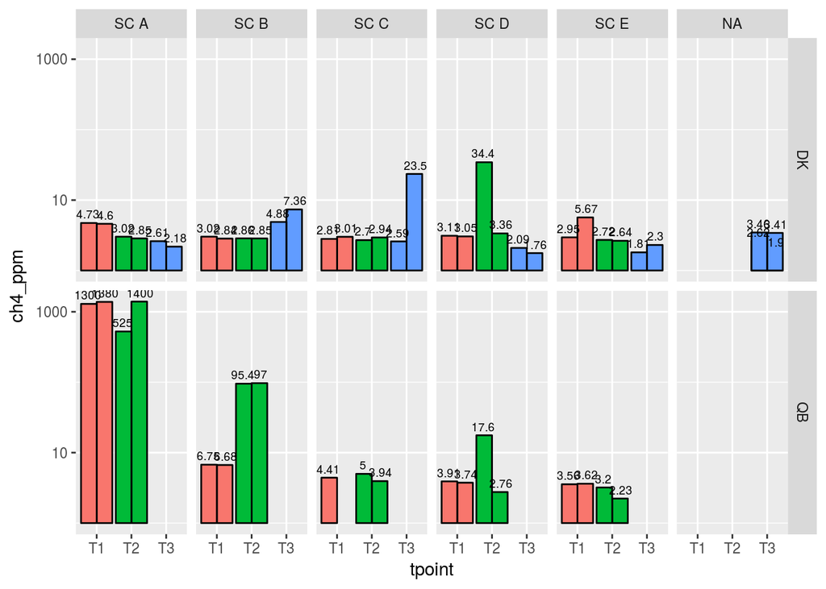

```r
sc1 <- chamb %>% group_by(Site, Method, Chamber_ID, tpoint) %>%
  ggplot(aes(x = tpoint, y = ch4_ppm, col = tpoint, group = Timepoint)) +
  geom_bar(colour="black", stat = "identity", position = position_dodge(), aes(fill = tpoint)) +
  scale_y_log10() + facet_grid(Site~Chamber_ID) +
  theme(legend.position="none") +
  geom_text(aes(label = signif(ch4_ppm, 3)),
            color = "black", size = 2.5,
            position = position_dodge(width = 1),
            vjust = -.5)
sc1
```

```r
# code to save sc1 as image with good dimensions
```

## boxplot

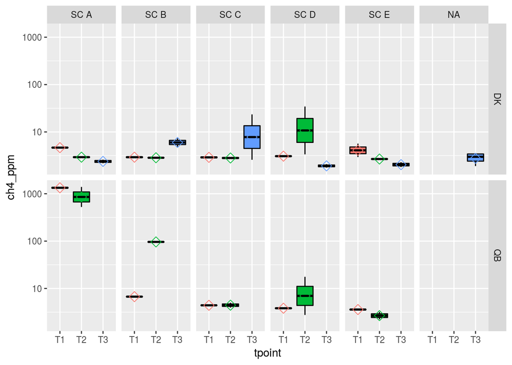

```r
sc2 <- chamb %>% group_by(Site, Method, Chamber_ID, tpoint) %>%
  ggplot(aes(x = tpoint, y = ch4_ppm, col = tpoint)) +
  geom_boxplot(colour="black", aes(fill = tpoint)) +
  stat_summary(fun.y=mean, geom="point", shape=5, size=3) +
  scale_y_log10() + facet_grid(Site~Chamber_ID) +
  theme(legend.position="none")
sc2
```

## line graphs

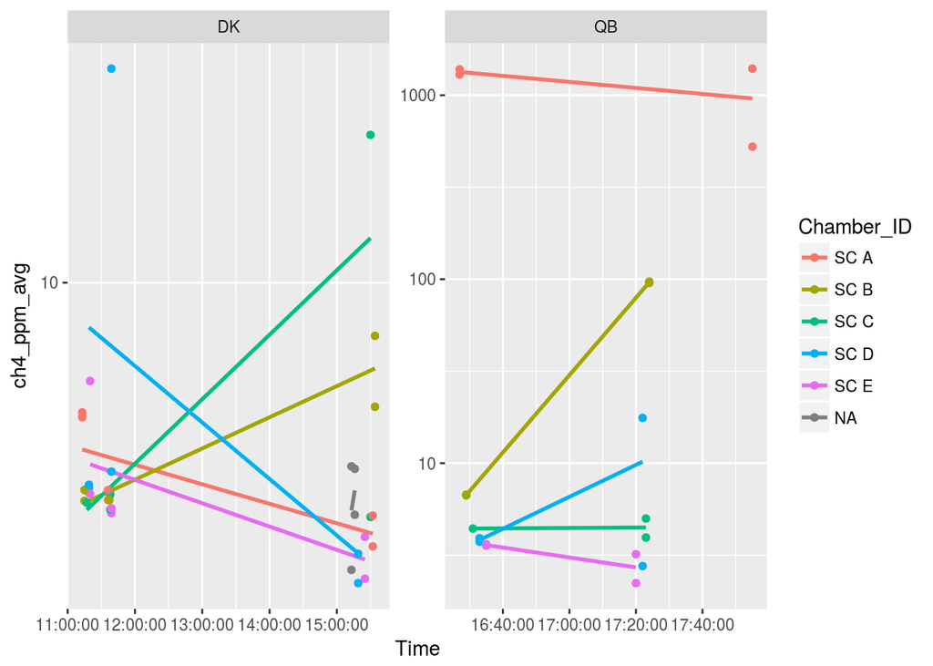

```r
chamb_avgs <- chamb %>% group_by(Site, Method, Chamber_ID, tpoint, Time) %>%
  summarise(ch4_ppm_avg = mean(ch4_ppm, na.rm = TRUE))

chamb_avgs %>%
  ggplot(aes(x = Time, y = ch4_ppm_avg, col = Chamber_ID)) +
  # geom_point() +
  # geom_line() +
  geom_smooth(method = "lm", se = FALSE) +
  facet_wrap(~Site, scales = "free") +
  scale_y_log10() +
  geom_point(data = chamb, aes(x = Time, y = ch4_ppm))
```

## CO2 peaks

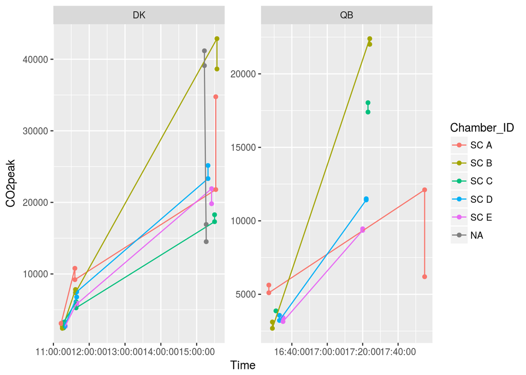

```r
chamb %>% group_by(Site, Method, Chamber_ID) %>%
  ggplot(aes(x = Time, y = CO2peak, col = Chamber_ID)) +
  geom_point() + geom_line() + facet_wrap(~Site, scales = "free")
```